# Revise & Resubmit – Reviewer Responses

July 2026

```r
r = readRDS("../Data_amalgamate/pre_processed_results.RDS")

# Binary treatment dummies (created in results.R but not in pre_processed_results)
for(tr in c("control","gap","gap_lie","mental_health","no_data","bad")){
  r[[tr]] = r$treatment == tr
}

bad = subset(r, treatment == "bad")

# Reverse-code potentialemployers to match results.R (line 126: 8 - x)
# Raw scale: 1 = Strongly Agree, 7 = Strongly Disagree
# After recode: higher = more pro-SM use by employers
r$potentialemployers_rc   = 8 - r$potentialemployers
bad$potentialemployers_rc = 8 - bad$potentialemployers
# SMcontents: 1-10, higher = evaluator thinks SM contents more important (no recode needed)
```

# Comment 1: Decomposing the Bad SM Treatment

> In my view the “Bad SM” treatment actually bundles together signals that plausibly differ in (i) how negative they are (ii) their job relevance. Negative tone and poor grammar are potentially informative for the job and clearly negative, while elements like gaming-related hashtags (e.g., #xbox) do not seem obviously negative (at least to me). If the underlying sample size permits, the authors could exploit this variation to examine whether weaker or more ambiguous signals generate similar penalties. As a placebo test, one would expect such weak signals not to drive strong negative evaluations.

## What does the Bad SM treatment contain?

**Hashtag slots** — Each evaluator sees exactly 4 hashtags: one drawn at random from each of three slots simultaneously:

| Slot | Hashtags |
| --- | --- |
| A — 1 of 3 | `#fortnite`, `#gaming`, `#xbox` |
| B — 1 of 3 | `#nosleep`, `#happyhour`, `#party` |
| C — 2 of 5 | `#fuckmylife`, `#tgif`, `#itsonlytuesday`, `#tired`, `#weekendvibes` |

**Group pools** — Each evaluator sees exactly 4 groups: two drawn at random from each of two pools:

| Pool | Groups |
| --- | --- |
| Negative work — 2 of 3 | `I Hate Monday Mornings`, `Work Sucks Meme Factory`, `I Love/Hate My Job` |
| Gaming — 2 of 7 | `Call of Duty`, `Borderlands`, `Pokemon Sword`, `Super Smash Bros`, `Monster Hunter World`, `Diablo`, `grand theft auto V` |

**Automatic Screening Report** — Fixed text, identical for all Bad SM participants: *“language generally neutral; interactions sometimes negative or offensive; spelling and grammar: bad.”* No variation across participants — cannot be separately identified.

**What comparisons are valid:** Because all three hashtag slots co-occur simultaneously (someone who got `#fortnite` also always got one hashtag from Slot B and two from Slot C), you cannot compare across slots — any apparent difference would be confounded by which other slots they co-occurred with. Valid comparisons are only **within** the same slot or pool. We therefore run one regression per slot/pool, with only that slot’s indicators as regressors (plus candidate controls). The other slots are orthogonal by design and omitted without bias.

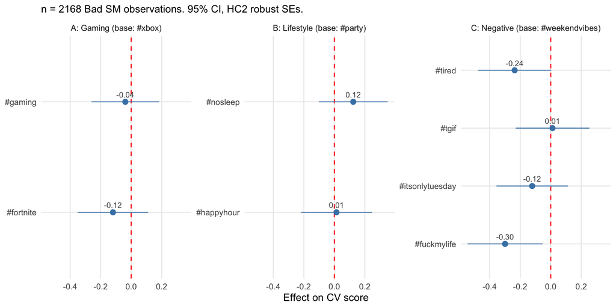

Within-slot hashtag comparisons. Each coefficient is the effect relative to the slot baseline (#xbox, #party, #weekendvibes). 95% CI, HC2 robust SEs.

```r
library(ggplot2)

tab_a = run_slot(c("fortnite","gaming","xbox"),     baseline_tag="xbox")
tab_b = run_slot(c("nosleep","happyhour","party"),  baseline_tag="party")
tab_c = run_slot(c("fuckmylife","tgif","itsonlytuesday","tired","weekendvibes"), baseline_tag="weekendvibes")

df_ht = rbind(
  cbind(Slot="A: Gaming (base: #xbox)",          tab_a[, c("Hashtag","Estimate","SE")]),
  cbind(Slot="B: Lifestyle (base: #party)",       tab_b[, c("Hashtag","Estimate","SE")]),
  cbind(Slot="C: Negative (base: #weekendvibes)", tab_c[, c("Hashtag","Estimate","SE")])
)
df_ht$ci_lo = df_ht$Estimate - 1.96 * df_ht$SE
df_ht$ci_hi = df_ht$Estimate + 1.96 * df_ht$SE
df_ht$Slot  = factor(df_ht$Slot, levels=unique(df_ht$Slot))

ggplot(df_ht, aes(x=Estimate, xmin=ci_lo, xmax=ci_hi, y=Hashtag)) +
  geom_vline(xintercept=0, colour="red", linetype="dashed", linewidth=0.6) +
  geom_pointrange(colour="steelblue", size=0.5) +
  geom_text(aes(label=sprintf("%.2f", Estimate)), vjust=-0.8, size=3.2, colour="grey30") +
  facet_wrap(~Slot, scales="free_y", ncol=3) +
  labs(x="Effect on CV score", y=NULL,
       subtitle=paste0("n = ", nrow(bad), " Bad SM observations. 95% CI, HC2 robust SEs.")) +
  theme_minimal(base_size=12) +
  theme(panel.grid.minor=element_blank())
```

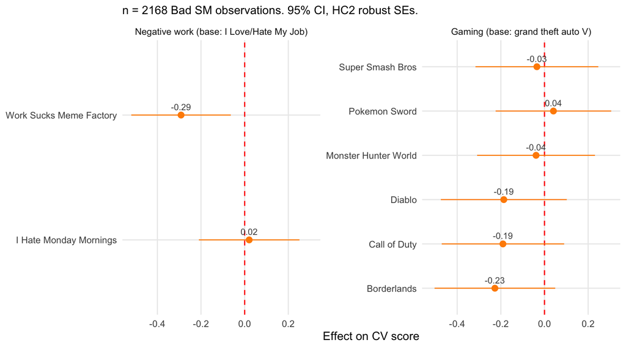

Within-pool group comparisons. Each coefficient is the effect relative to the pool baseline. 95% CI, HC2 robust SEs.

```r
negwork_groups = c("I Hate Monday Mornings","Work Sucks Meme Factory","I Love/Hate My Job")
gaming_groups  = c("Call of Duty","Borderlands","Pokemon Sword","Super Smash Bros",
                   "Monster Hunter World","Diablo","grand theft auto V")

tab_nw = run_grp_pool(negwork_groups, baseline_group="I Love/Hate My Job")
tab_gm = run_grp_pool(gaming_groups,  baseline_group="grand theft auto V")

df_gr = rbind(
  cbind(Pool="Negative work (base: I Love/Hate My Job)", tab_nw[, c("Group","Estimate","SE")]),
  cbind(Pool="Gaming (base: grand theft auto V)",         tab_gm[, c("Group","Estimate","SE")])
)
df_gr$ci_lo = df_gr$Estimate - 1.96 * df_gr$SE
df_gr$ci_hi = df_gr$Estimate + 1.96 * df_gr$SE
df_gr$Pool  = factor(df_gr$Pool, levels=unique(df_gr$Pool))

ggplot(df_gr, aes(x=Estimate, xmin=ci_lo, xmax=ci_hi, y=Group)) +
  geom_vline(xintercept=0, colour="red", linetype="dashed", linewidth=0.6) +
  geom_pointrange(colour="darkorange", size=0.5) +
  geom_text(aes(label=sprintf("%.2f", Estimate)), vjust=-0.8, size=3.2, colour="grey30") +
  facet_wrap(~Pool, scales="free_y", ncol=2) +
  labs(x="Effect on CV score", y=NULL,
       subtitle=paste0("n = ", nrow(bad), " Bad SM observations. 95% CI, HC2 robust SEs.")) +
  theme_minimal(base_size=12) +
  theme(panel.grid.minor=element_blank())
```

# Comment 2: Do Evaluators Who Think SM is Unimportant Still Respond?

> Do people who think social media is not important still respond strongly? If the critiques above hold, even evaluators who don’t believe social media matters will still use it. That’s not the same as “Are effects larger for people who think it is important?” (Table 2).

We examine this using two evaluator-level variables:

- **`potentialemployers`**: “Potential and/or existing employers should use information found on social networking pages to make decisions about prospective and/or existing employees.” 7-point scale; in the raw data 1 = Strongly Agree, 7 = Strongly Disagree. Reverse-coded so that higher = more pro-SM use.
- **`SMcontents`**: “How important are the contents of the applicant’s social media accounts for the recruitment process.” 1–10 scale; higher = more important. No recoding needed.

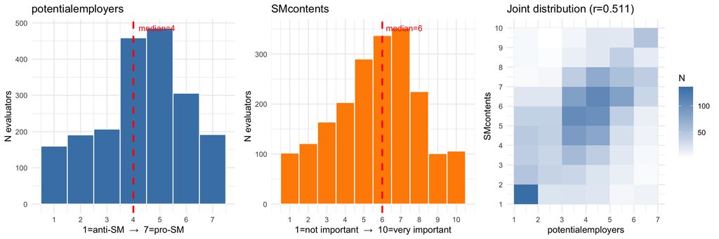

Left two panels: distributions of evaluator SM belief variables (dashed line = median). Right: joint distribution (r = Pearson correlation). Unique evaluators only.

```r
library(ggplot2)
library(gridExtra)

evals = r[!duplicated(r$mturkID) & !is.na(r$potentialemployers_rc) & !is.na(r$SMcontents), ]
pe_med  = median(evals$potentialemployers_rc, na.rm=TRUE)
smc_med = median(evals$SMcontents, na.rm=TRUE)
cor_val = round(cor(evals$potentialemployers_rc, evals$SMcontents, use="complete.obs"), 3)

p1 = ggplot(evals, aes(x=potentialemployers_rc)) +
  geom_histogram(binwidth=1, fill="steelblue", colour="white") +
  geom_vline(xintercept=pe_med, linetype="dashed", colour="red", linewidth=1) +
  annotate("text", x=pe_med+0.2, y=Inf, label=paste0("median=",pe_med),
           vjust=2, hjust=0, colour="red", size=3.5) +
  scale_x_continuous(breaks=1:7) +
  labs(title="potentialemployers", x="1=anti-SM  →  7=pro-SM", y="N evaluators") +
  theme_minimal()

p2 = ggplot(evals, aes(x=SMcontents)) +
  geom_histogram(binwidth=1, fill="darkorange", colour="white") +
  geom_vline(xintercept=smc_med, linetype="dashed", colour="red", linewidth=1) +
  annotate("text", x=smc_med+0.2, y=Inf, label=paste0("median=",smc_med),
           vjust=2, hjust=0, colour="red", size=3.5) +
  scale_x_continuous(breaks=1:10) +
  labs(title="SMcontents", x="1=not important  →  10=very important", y="N evaluators") +
  theme_minimal()

p3 = ggplot(evals, aes(x=potentialemployers_rc, y=SMcontents)) +
  geom_bin2d(binwidth=c(1,1)) +
  scale_fill_gradient(low="white", high="steelblue") +
  scale_x_continuous(breaks=1:7) +
  scale_y_continuous(breaks=1:10) +
  labs(title=paste0("Joint distribution (r=", cor_val, ")"),
       x="potentialemployers", y="SMcontents", fill="N") +
  theme_minimal()

grid.arrange(p1, p2, p3, ncol=3)
```

## Coefficient plots by SM belief subgroup

Each panel shows treatment effects estimated separately within subgroups defined by the evaluator’s SM belief score. The split variable is dropped from the regression formula (as in the paper), so it does not act as a control within the subgroup regression.

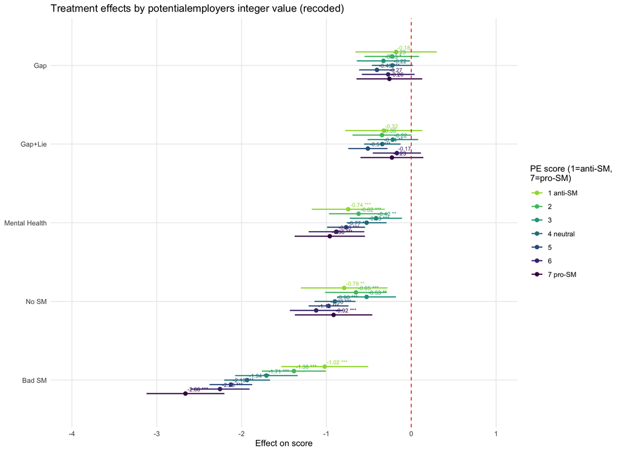

Treatment effects split by each integer value of potentialemployers (Results.RDS already recoded: 1 = anti-SM / Strongly Disagree, 7 = pro-SM / Strongly Agree). General public only. Sample sizes (obs / evaluators): pe=1: 708/118, pe=2: 864/144, pe=3: 990/165, pe=4: 2130/355, pe=5: 2178/363, pe=6: 1368/228, pe=7: 762/127.

```r
pe_int_indexes = lapply(1:7, function(v) Res$potentialemployers == v)
pe_int_labels  = c("1 anti-SM", "2", "3", "4 neutral", "5", "6", "7 pro-SM")

pe_int_models = run_subgroup_models(formula_vars_cp, pe_int_indexes, split_var="potentialemployers")

plot_models(pe_int_models,
            m.labels     = pe_int_labels,
            rm.terms     = treats_rm,
            axis.labels  = rev(c("Gap", "Gap+Lie", "Mental Health", "No SM", "Bad SM")),
            legend.title = "PE score (1=anti-SM, 7=pro-SM)",
            show.values  = TRUE,
            value.size   = 2.5,
            dot.size     = 2,
            colors       = "viridis") +
  geom_hline(yintercept=0, colour="red", linetype="dashed") +
  labs(title="Treatment effects by potentialemployers integer value (recoded)", x=NULL, y="Effect on score") +
  theme_minimal() +
  theme(panel.grid.minor.x=element_blank())
```

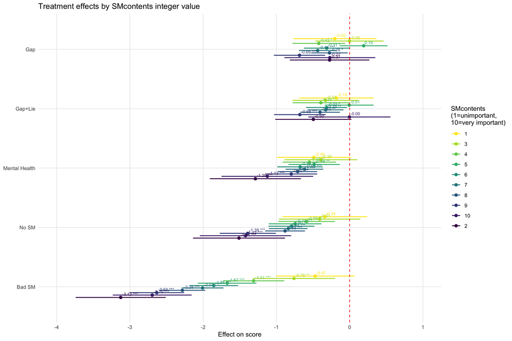

Treatment effects split by each integer value of SMcontents (1=SM not important at all, 10=very important). General public only.

```r
smc_int_indexes = lapply(1:10, function(v) Res$SMcontents == v)
smc_int_labels  = as.character(1:10)

smc_int_models = run_subgroup_models(formula_vars_cp, smc_int_indexes, split_var="SMcontents")

plot_models(smc_int_models,
            m.labels     = smc_int_labels,
            rm.terms     = treats_rm,
            axis.labels  = rev(c("Gap", "Gap+Lie", "Mental Health", "No SM", "Bad SM")),
            legend.title = "SMcontents (1=unimportant, 10=very important)",
            show.values  = TRUE,
            value.size   = 2.5,
            dot.size     = 2,
            colors       = scales::viridis_pal()(10)) +
  geom_hline(yintercept=0, colour="red", linetype="dashed") +
  labs(title="Treatment effects by SMcontents integer value", x=NULL, y="Effect on score") +
  theme_minimal() +
  theme(panel.grid.minor.x=element_blank())
```

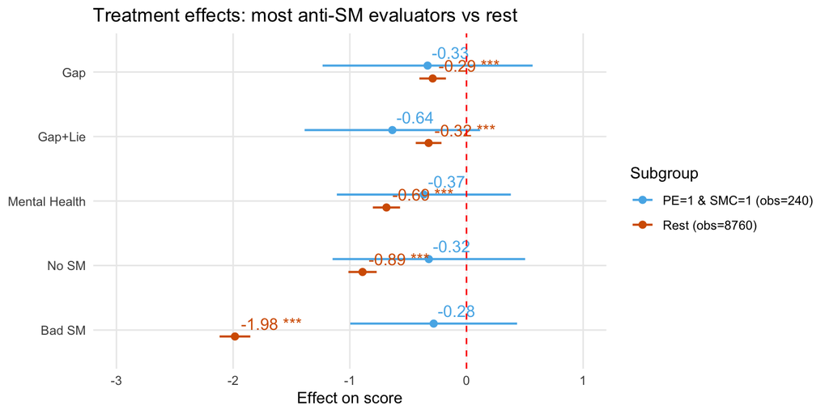

Treatment effects for evaluators scoring 1 on both potentialemployers (strongly disagrees employers should use SM) and SMcontents (SM not at all important), compared to all other evaluators. General public only.

```r
bothlow_idx  = Res$potentialemployers == 1 & Res$SMcontents == 1
rest_idx     = !(Res$potentialemployers == 1 & Res$SMcontents == 1)
n_both = sum(bothlow_idx & wave_idx, na.rm=TRUE)
n_rest = sum(rest_idx   & wave_idx, na.rm=TRUE)

bothlow_models = run_subgroup_models(
  formula_vars_cp,
  list(bothlow_idx, rest_idx),
  split_var = character(0)
)

plot_models(bothlow_models,
            m.labels    = c(paste0("PE=1 & SMC=1 (obs=", n_both, ")"),
                            paste0("Rest (obs=", n_rest, ")")),
            rm.terms    = treats_rm,
            axis.labels = rev(c("Gap", "Gap+Lie", "Mental Health", "No SM", "Bad SM")),
            legend.title = "Subgroup",
            show.values = TRUE,
            dot.size    = 2,
            colors      = c("#D55E00","#56B4E9")) +
  geom_hline(yintercept=0, colour="red", linetype="dashed") +
  labs(title="Treatment effects: most anti-SM evaluators vs rest", x=NULL, y="Effect on score") +
  theme_minimal() +
  theme(panel.grid.minor.x=element_blank())
```

# Comment 3: Using Open-Text Notes to Shed Light on Mechanisms

> If the open-text responses are of sufficient quality, they could be used more systematically to shed light on mechanisms. A classification of notes, combined with survey measures of beliefs about the importance of social media, could be informative e.g., if evaluators who report that social media is unimportant nevertheless rely on it in their notes, this would support a salience or experimenter demand interpretation.

## Results from LLM note classification

*This section runs only when `note_classifications.csv` exists.*

```r
library(ggplot2)
library(dplyr)
if(!requireNamespace("patchwork", quietly=TRUE)) install.packages("patchwork")
library(patchwork)

nc = read.csv("note_classifications.csv", stringsAsFactors=FALSE)

# CSV booleans arrive as strings "True"/"False" from Python — convert
bool_cols = c("mentions_sm","mentions_gap","mentions_mental_health",
              "mentions_hashtags","mentions_groups","mentions_grammar","empty")
for(col in intersect(bool_cols, colnames(nc))){
  nc[[col]] = nc[[col]] == "True"
}

# Split into notes vs feedback rows  (CSV column is row_type, not type)
notes_df    = subset(nc, row_type == "note")
feedback_df = subset(nc, row_type == "feedback")

# Drop empty notes from mentions_sm analysis — if no text, no mention possible
# (classifier flagged 84% of empty notes as mentioning SM — clear over-classification)
notes_df$mentions_sm_clean = notes_df$mentions_sm & !notes_df$empty

non_empty = subset(notes_df, !empty)

# Evaluator-level: did any note mention SM?
eval_sm = notes_df %>%
  group_by(mturkID) %>%
  summarise(
    any_sm     = any(mentions_sm_clean, na.rm=TRUE),
    n_nonempty = sum(!empty),
    n_sm_clean = sum(mentions_sm_clean, na.rm=TRUE),
    share_sm   = ifelse(sum(!empty)>0, sum(mentions_sm_clean)/sum(!empty), NA_real_),
    .groups = "drop"
  )

# Join evaluator SM belief variables (Results.RDS already recoded: pe 1=anti-SM, 7=pro-SM)
Res_ev_1 = readRDS("../Data_amalgamate/Results.RDS")
Res_ev_1 = Res_ev_1[!duplicated(Res_ev_1$mturkID),
                    c("mturkID","potentialemployers","SMcontents","wave")]
eval_sm = merge(eval_sm, Res_ev_1, by="mturkID", all.x=TRUE)

# Join experimenter demand belief from feedback rows
fb_belief = feedback_df[, c("mturkID","exp_belief")]
eval_sm   = merge(eval_sm, fb_belief, by="mturkID", all.x=TRUE)
eval_sm$exp_belief[is.na(eval_sm$exp_belief) | eval_sm$exp_belief == ""] = "unclear"
```

**`mentions_sm`** — Did the evaluator mention social media at all in their written note? This is the key variable for the reviewer’s mechanism question: if even evaluators who say SM is unimportant still write about it, that supports a salience interpretation. Empty notes are excluded (classifier over-flags empties).

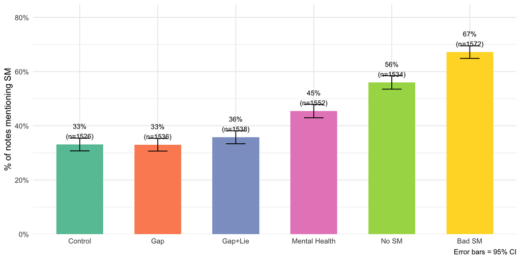

```r
notes_by_tr = non_empty %>%
  group_by(treatment) %>%
  summarise(
    n     = n(),
    n_sm  = sum(mentions_sm, na.rm=TRUE),
    pct   = n_sm / n,
    se    = sqrt(pct*(1-pct)/n),
    ci_lo = pmax(0, pct - 1.96*se),
    ci_hi = pmin(1, pct + 1.96*se),
    .groups="drop"
  ) %>%
  mutate(treatment = factor(treatment,
    levels=c("control","gap","gap_lie","mental_health","no_data","bad"),
    labels=c("Control","Gap","Gap+Lie","Mental Health","No SM","Bad SM")))

ggplot(notes_by_tr, aes(x=treatment, y=pct, fill=treatment)) +
  geom_col(show.legend=FALSE, width=0.6) +
  geom_errorbar(aes(ymin=ci_lo, ymax=ci_hi), width=0.25) +
  geom_text(aes(label=sprintf("%.0f%%\n(n=%d)", pct*100, n)),
            vjust=-0.4, size=3) +
  scale_y_continuous(labels=scales::percent_format(),
                     expand=expansion(mult=c(0, 0.22))) +
  scale_fill_brewer(palette="Set2") +
  labs(x=NULL, y="% of notes mentioning SM",
       caption="Error bars = 95% CI") +
  theme_minimal()
```

**`SMcontents`** — “How important are the contents of the applicant’s social media accounts for the recruitment process?” (1–10; higher = more important). **`potentialemployers`** — “Potential employers should use information found on social networking pages to make decisions about employees.” (1 = anti-SM / Strongly Disagree, 7 = pro-SM / Strongly Agree, after recoding).

The key question: do evaluators who say SM is *unimportant* still write about it?

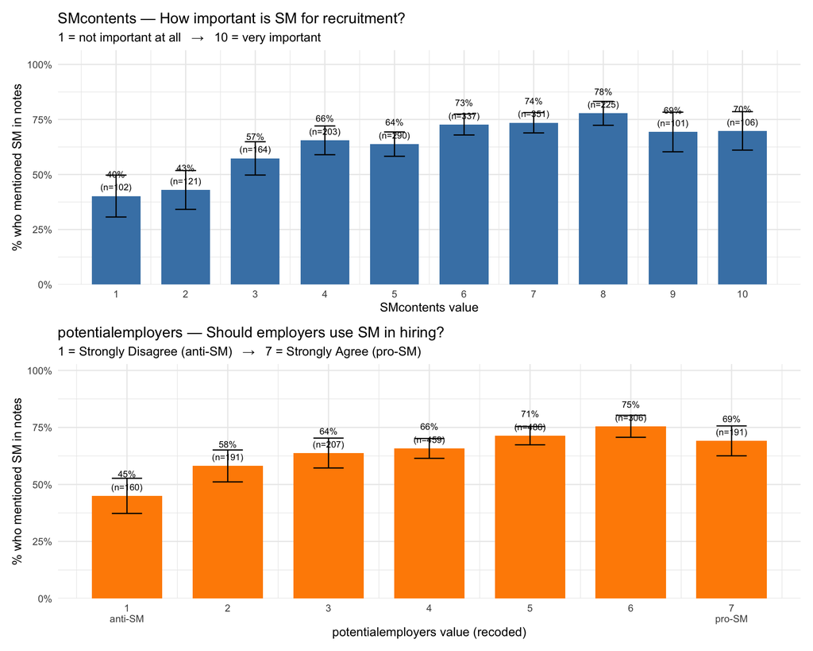

% of evaluators who mentioned SM in at least one note, by SM belief score. 95% CI. N shown above each bar.

```r
sm_by_smc = eval_sm %>%
  filter(!is.na(SMcontents)) %>%
  group_by(SMcontents) %>%
  summarise(
    pct   = mean(any_sm, na.rm=TRUE),
    n     = n(),
    se    = sqrt(pct*(1-pct)/n),
    ci_lo = pmax(0, pct - 1.96*se),
    ci_hi = pmin(1, pct + 1.96*se),
    .groups="drop"
  )

sm_by_pe = eval_sm %>%
  filter(!is.na(potentialemployers)) %>%
  group_by(potentialemployers) %>%
  summarise(
    pct   = mean(any_sm, na.rm=TRUE),
    n     = n(),
    se    = sqrt(pct*(1-pct)/n),
    ci_lo = pmax(0, pct - 1.96*se),
    ci_hi = pmin(1, pct + 1.96*se),
    .groups="drop"
  )

p_smc = ggplot(sm_by_smc, aes(x=SMcontents, y=pct)) +
  geom_col(fill="steelblue", width=0.7) +
  geom_errorbar(aes(ymin=ci_lo, ymax=ci_hi), width=0.3) +
  geom_text(aes(label=sprintf("%.0f%%\n(n=%d)", pct*100, n)),
            vjust=-0.3, size=2.8) +
  scale_x_continuous(breaks=1:10) +
  scale_y_continuous(labels=scales::percent_format(),
                     expand=expansion(mult=c(0, 0.28))) +
  labs(title="SMcontents — How important is SM for recruitment?",
       subtitle="1 = not important at all   →   10 = very important",
       x="SMcontents value", y="% who mentioned SM in notes") +
  theme_minimal()

p_pe = ggplot(sm_by_pe, aes(x=potentialemployers, y=pct)) +
  geom_col(fill="darkorange", width=0.7) +
  geom_errorbar(aes(ymin=ci_lo, ymax=ci_hi), width=0.3) +
  geom_text(aes(label=sprintf("%.0f%%\n(n=%d)", pct*100, n)),
            vjust=-0.3, size=2.8) +
  scale_x_continuous(breaks=1:7,
    labels=c("1\nanti-SM","2","3","4","5","6","7\npro-SM")) +
  scale_y_continuous(labels=scales::percent_format(),
                     expand=expansion(mult=c(0, 0.28))) +
  labs(title="potentialemployers — Should employers use SM in hiring?",
       subtitle="1 = Strongly Disagree (anti-SM)   →   7 = Strongly Agree (pro-SM)",
       x="potentialemployers value (recoded)", y="% who mentioned SM in notes") +
  theme_minimal()

p_smc / p_pe
```

**`sm_sentiment`** — overall sentiment of SM-related content in the note (positive / negative / mixed / neutral / not mentioned). **`mentions_grammar`** — evaluator specifically noted bad grammar or language quality. **`mentions_hashtags`** / **`mentions_groups`** — evaluator noted specific hashtags or group memberships. **`mentions_gap`** / **`mentions_mental_health`** — evaluator noted the employment gap or mental health disclosure.

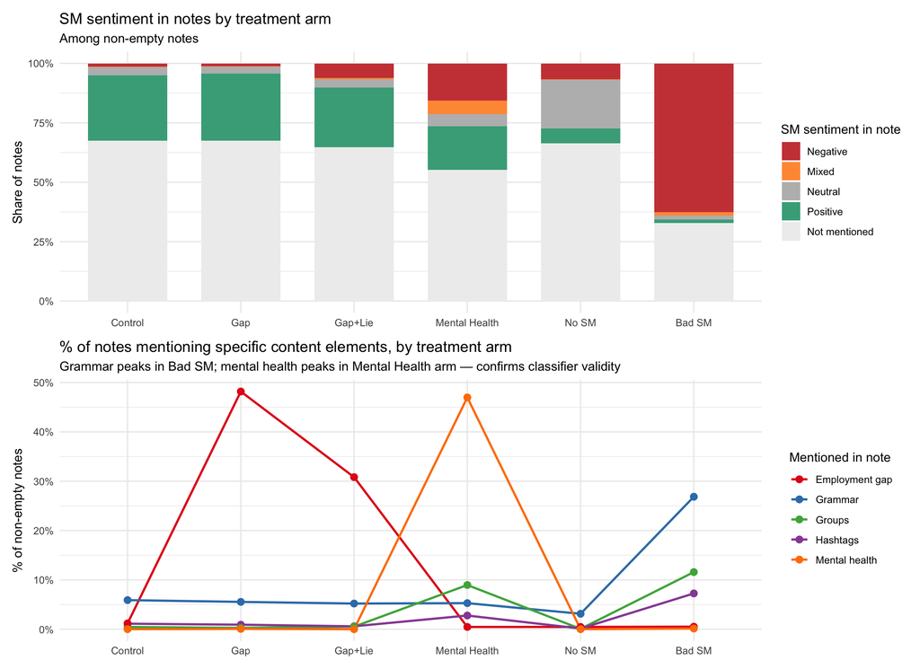

Top: SM sentiment in notes by treatment. Bottom: % of notes mentioning specific content elements by treatment.

```r
library(tidyr)

# SM sentiment by treatment
sent_by_tr = non_empty %>%
  group_by(treatment, sm_sentiment) %>%
  summarise(n=n(), .groups="drop") %>%
  group_by(treatment) %>%
  mutate(pct = n/sum(n)) %>%
  ungroup() %>%
  mutate(
    treatment    = factor(treatment,
      levels=c("control","gap","gap_lie","mental_health","no_data","bad"),
      labels=c("Control","Gap","Gap+Lie","Mental Health","No SM","Bad SM")),
    sm_sentiment = factor(sm_sentiment,
      levels=c("negative","mixed","neutral","positive","not_mentioned"),
      labels=c("Negative","Mixed","Neutral","Positive","Not mentioned"))
  )

p_sent = ggplot(sent_by_tr, aes(x=treatment, y=pct, fill=sm_sentiment)) +
  geom_col(position="fill", width=0.7) +
  scale_fill_manual(
    values=c(Negative="#CC4444", Mixed="#FF9944", Neutral="#BBBBBB",
             Positive="#44AA88", `Not mentioned`="#EEEEEE"),
    name="SM sentiment in note") +
  scale_y_continuous(labels=scales::percent_format()) +
  labs(title="SM sentiment in notes by treatment arm",
       subtitle="Among non-empty notes",
       x=NULL, y="Share of notes") +
  theme_minimal()

# Specific content element mentions by treatment
comp_long = non_empty %>%
  group_by(treatment) %>%
  summarise(
    Grammar          = mean(mentions_grammar,       na.rm=TRUE),
    Hashtags         = mean(mentions_hashtags,      na.rm=TRUE),
    Groups           = mean(mentions_groups,        na.rm=TRUE),
    `Employment gap` = mean(mentions_gap,           na.rm=TRUE),
    `Mental health`  = mean(mentions_mental_health, na.rm=TRUE),
    .groups="drop"
  ) %>%
  pivot_longer(-treatment, names_to="Element", values_to="pct") %>%
  mutate(treatment = factor(treatment,
    levels=c("control","gap","gap_lie","mental_health","no_data","bad"),
    labels=c("Control","Gap","Gap+Lie","Mental Health","No SM","Bad SM")))

p_comp = ggplot(comp_long, aes(x=treatment, y=pct, colour=Element, group=Element)) +
  geom_line(linewidth=0.9) +
  geom_point(size=2.5) +
  scale_y_continuous(labels=scales::percent_format()) +
  scale_colour_brewer(palette="Set1", name="Mentioned in note") +
  labs(title="% of notes mentioning specific content elements, by treatment arm",
       subtitle="Grammar peaks in Bad SM; mental health peaks in Mental Health arm — confirms classifier validity",
       x=NULL, y="% of non-empty notes") +
  theme_minimal()

p_sent / p_comp
```

## Did noticing the gap change the treatment effect?

For evaluators in the gap and gap+lie arms: did those who explicitly mentioned the employment gap in their note respond differently? We classify each evaluator by whether their note mentioned the gap in the **gap** CV, the **gap+lie** CV, or both.

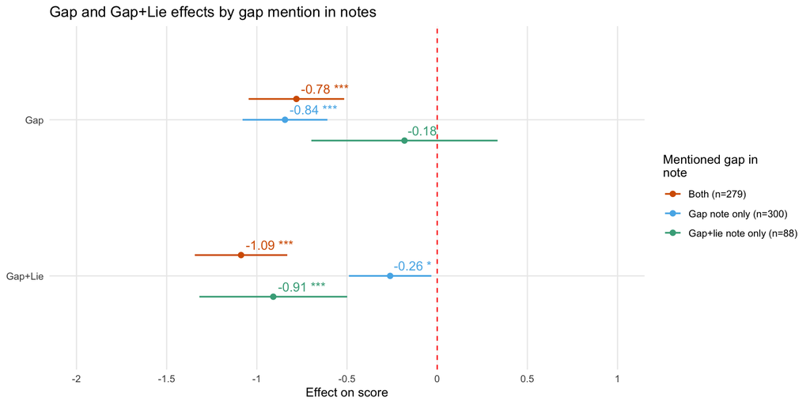

Gap and Gap+Lie treatment effects by whether the evaluator mentioned the employment gap in their notes. Groups are mutually exclusive at the evaluator level. General public only.

```r
gap_notes = notes_df[notes_df$treatment %in% c("gap","gap_lie"),
                     c("mturkID","treatment","mentions_gap")]

gap_wide = gap_notes %>%
  group_by(mturkID, treatment) %>%
  slice(1) %>%
  ungroup() %>%
  pivot_wider(id_cols=mturkID, names_from=treatment, values_from=mentions_gap)
colnames(gap_wide)[colnames(gap_wide)=="gap_lie"] = "gap_lie"

gap_wide = gap_wide %>%
  mutate(
    mention_group = case_when(
      gap == TRUE  & gap_lie == TRUE  ~ "Both",
      gap == TRUE  & gap_lie == FALSE ~ "Gap note only",
      gap == FALSE & gap_lie == TRUE  ~ "Gap+lie note only",
      TRUE                            ~ "Neither"
    )
  )

g_both   = Res$mturkID %in% gap_wide$mturkID[gap_wide$mention_group == "Both"]
g_gap    = Res$mturkID %in% gap_wide$mturkID[gap_wide$mention_group == "Gap note only"]
g_gaplie = Res$mturkID %in% gap_wide$mturkID[gap_wide$mention_group == "Gap+lie note only"]

n_both   = length(unique(Res$mturkID[g_both   & wave_idx]))
n_gap    = length(unique(Res$mturkID[g_gap    & wave_idx]))
n_gaplie = length(unique(Res$mturkID[g_gaplie & wave_idx]))

gap_group_models = run_subgroup_models(
  formula_vars_cp,
  list(g_both, g_gap, g_gaplie),
  split_var = character(0)
)

plot_models(gap_group_models,
            m.labels     = c(paste0("Both (n=", n_both, ")"),
                             paste0("Gap note only (n=", n_gap, ")"),
                             paste0("Gap+lie note only (n=", n_gaplie, ")")),
            rm.terms     = c(treats_rm, "mental_health", "no_data", "bad"),
            axis.labels  = rev(c("Gap", "Gap+Lie")),
            legend.title = "Mentioned gap in note",
            show.values  = TRUE,
            dot.size     = 2,
            colors       = c("#44AA88","#56B4E9","#D55E00")) +
  geom_hline(yintercept=0, colour="red", linetype="dashed") +
  labs(title="Gap and Gap+Lie effects by gap mention in notes",
       x=NULL, y="Effect on score") +
  theme_minimal() +
  theme(panel.grid.minor.x=element_blank())
```

# Comment 4: Multiple Hypothesis Testing

> I think the heterogeneity tests should be adjusted for multiple hypothesis testing. It would be helpful to have more information on how the Prolific sample was recruited – I gather this sample knew they were in an experiment, so what was posted on Prolific, was there some kind of consent form and did either of these reveal anything about the study purpose?

Three correction methods compared — from most to least conservative:

| Method | What it controls | How it works |
| --- | --- | --- |
| **Bonferroni** *(most conservative)* | Family-Wise Error Rate (FWER) | Multiply each p-value by the number of tests. Assumes independence — overly conservative when tests are correlated. |
| **Holm (step-down Bonferroni)** | FWER | Sort p-values smallest to largest; multiply the smallest by *k*, the next by *k*−1, etc. Always at least as powerful as Bonferroni. |
| **Benjamini-Hochberg (BH / FDR)** *(least conservative)* | False Discovery Rate | Controls the expected *proportion* of false positives among rejected tests, not the probability of *any* false positive. More powerful than FWER methods, especially with many tests. |

**Prolific recruitment note:** The Prolific posting text and consent form are not in the data files and must be located and quoted separately.

## MHT for Table 2: interaction terms

Table 2 uses the paper’s specification: one `felm` regression per evaluator characteristic per wave, each including that characteristic interacted with all 5 treatment dummies. This gives **10 covariates × 5 treatments = 50 tests per wave**, corrected independently within each wave using BH — the two waves are treated as separate replication samples, so each forms its own family of 50 tests.

*(The document previously said “5 × 11 = 55” — this was from an earlier, incorrect specification. The correct count is 50 tests per wave = 10 covariates × 5 treatments.)*

**The 10 evaluator characteristics in Table 2:**

| # | Label in table | Variable | Description |
| --- | --- | --- | --- |
| 1 | Eval. Female | `participant.Female` | Evaluator gender (binary) |
| 2 | Age | `age` | Evaluator age |
| 3 | Conservative | `lib_con` | Liberal–conservative self-placement (1 = very liberal, 7 = very conservative) |
| 4 | Active on SM | `SM_active` | Active social media user (binary) |
| 5 | Graduate | `graduate` | Holds a graduate degree (binary) |
| 6 | SM Approval | `SM_approval2` | `stayintouch + toomuchtime` — approval of SM for social use |
| 7 | Employers use SM | `potentialemployers` | “Employers should use SM for hiring” (1 = anti-SM, 7 = pro-SM after recoding) |
| 8 | Prof. SM Imp. | `professional` | Importance of professional SM presence |
| 9 | Privacy | `privacy_no_problem` | Comfort with SM privacy |
| 10 | SM Contents Imp. | `SMcontents` | “How important are SM contents for recruitment?” (1–10) |

**Additional SM-attitude variables in the data but not in Table 2:** `lostControl` (felt control over personal information), `advertisers` (advertisers should use SM data), `employers` (a separate employers-should-use-SM item), `stayintouch` and `toomuchtime` (the two components of SM Approval individually), `proSM` (composite pro-SM score), `SM_approval` (an alternative approval measure), and platform-use dummies: Twitter, Instagram, Facebook, Snapchat, LinkedIn, TikTok. Including all of these would expand the test count to 230 total (115 per wave: 23 covariates × 5 treatments).

```r
# One felm per covariate × wave, matching the paper's interaction table.R spec exactly.
# Results.RDS is already recoded (potentialemployers: 1=anti-SM, 7=pro-SM) — no 8-x applied here.

LM2 = readRDS("../Data_amalgamate/Results.RDS")
LM2$SM_approval2 = LM2$stayintouch + LM2$toomuchtime   # only var not pre-computed in Results.RDS

treat_vars_it2   = c("gap","gap_lie","mental_health","no_data","bad")
treat_labels_it2 = c("Gap","Gap+Lie","Mental Health","No SM","Bad SM")

formula_base_it2 = c("gap","gap_lie","mental_health","no_data","bad",
                     "experience_years","education_yt","skills_1.2","interests_1.2",
                     "endorsements","Order","applicant.Female")

covariates_it2 = c("participant.Female","age","lib_con","SM_active","graduate",
                   "SM_approval2","potentialemployers","professional","privacy_no_problem","SMcontents")
cov_labels_it2 = c("Eval. Female","Age","Conservative","Active on SM","Graduate",
                   "SM Approval","Employers use SM","Prof. SM Imp.","Privacy","SM Contents Imp.")

scaletab_it2 = function(df, fvars, index){
  for(v in fvars){
    if(is.numeric(df[[v]])){
      p05 = quantile(df[[v]], 0.05, na.rm=TRUE)
      p95 = quantile(df[[v]], 0.95, na.rm=TRUE)
      if(p95 > p05) df[[v]] = (df[[v]] - mean(df[[v]], na.rm=TRUE)) / (p95 - p05)
    }
  }
  subset(df, index)
}

# Use the [2]-occurrence approach from the original interaction table.R:
# first occurrence of each treatment dummy = main effect; second = interaction with covariate.
treat_fc2 = c("gapTRUE","gap_lieTRUE","mental_healthTRUE","no_dataTRUE","badTRUE")

run_interact2 = function(name, wave_label){
  inter_vars = paste0(name, ":", treat_vars_it2)
  fvars      = c(formula_base_it2, name, inter_vars)
  idx        = LM2$wave == wave_label
  tab        = scaletab_it2(LM2, fvars, idx)
  f          = as.formula(paste("CV_score ~", paste(fvars, collapse="+"), "| 0 | 0 | mturkID"))
  fit        = felm(keepX=TRUE, formula=f, data=tab)
  rn         = rownames(fit$coefficients)
  int_rows   = sapply(treat_fc2, function(tn){
    occ = which(grepl(tn, rn, fixed=TRUE))
    if(length(occ) >= 2) occ[2] else NA_integer_
  })
  list(
    coefs = fit$coefficients[int_rows],
    ses   = fit$cse[int_rows],
    pvals = fit$cpval[int_rows]
  )
}

n_cov2 = length(covariates_it2)
coef_mat2 = matrix(NA, nrow=n_cov2*2, ncol=5)
se_mat2   = matrix(NA, nrow=n_cov2*2, ncol=5)
pval_mat2 = matrix(NA, nrow=n_cov2*2, ncol=5)
row_labels2 = character(n_cov2*2)

for(i in seq_along(covariates_it2)){
  cov = covariates_it2[i]
  for(w in 1:2){
    wave_label = c("Original","Recruiters")[w]
    row_i = (i-1)*2 + w
    res_i = tryCatch(run_interact2(cov, wave_label),
                     error=function(e) list(coefs=rep(NA,5), ses=rep(NA,5), pvals=rep(NA,5)))
    coef_mat2[row_i,] = unname(res_i$coefs)
    se_mat2[row_i,]   = unname(res_i$ses)
    pval_mat2[row_i,] = unname(res_i$pvals)
    row_labels2[row_i] = paste0(cov_labels_it2[i], " (", wave_label, ")")
  }
}
colnames(coef_mat2) = treat_labels_it2
colnames(pval_mat2) = treat_labels_it2
rownames(coef_mat2) = row_labels2
rownames(pval_mat2) = row_labels2

# Per-wave BH correction: odd rows = Original wave, even rows = Recruiters wave
# Each wave corrected independently (50 tests: 10 covariates × 5 treatments)
orig_rows = seq(1, n_cov2*2, by=2)
recr_rows = seq(2, n_cov2*2, by=2)

bh_mat2   = matrix(NA, nrow=n_cov2*2, ncol=5)
bonf_mat2 = matrix(NA, nrow=n_cov2*2, ncol=5)
holm_mat2 = matrix(NA, nrow=n_cov2*2, ncol=5)

bh_mat2[orig_rows, ]   = matrix(p.adjust(as.vector(pval_mat2[orig_rows, ]), method="BH"),          nrow=n_cov2, ncol=5)
bh_mat2[recr_rows, ]   = matrix(p.adjust(as.vector(pval_mat2[recr_rows, ]), method="BH"),          nrow=n_cov2, ncol=5)
bonf_mat2[orig_rows, ] = matrix(p.adjust(as.vector(pval_mat2[orig_rows, ]), method="bonferroni"),  nrow=n_cov2, ncol=5)
bonf_mat2[recr_rows, ] = matrix(p.adjust(as.vector(pval_mat2[recr_rows, ]), method="bonferroni"),  nrow=n_cov2, ncol=5)
holm_mat2[orig_rows, ] = matrix(p.adjust(as.vector(pval_mat2[orig_rows, ]), method="holm"),        nrow=n_cov2, ncol=5)
holm_mat2[recr_rows, ] = matrix(p.adjust(as.vector(pval_mat2[recr_rows, ]), method="holm"),        nrow=n_cov2, ncol=5)

colnames(bh_mat2) = colnames(bonf_mat2) = colnames(holm_mat2) = treat_labels_it2
rownames(bh_mat2) = rownames(bonf_mat2) = rownames(holm_mat2) = row_labels2
```

```r
pv_orig = pval_mat2[orig_rows, ]
pv_recr = pval_mat2[recr_rows, ]
bh_orig = bh_mat2[orig_rows, ]
bh_recr = bh_mat2[recr_rows, ]
bo_orig = bonf_mat2[orig_rows, ]
bo_recr = bonf_mat2[recr_rows, ]
ho_orig = holm_mat2[orig_rows, ]
ho_recr = holm_mat2[recr_rows, ]

count_sig  = function(m, thr=0.05) sum(m < thr,  na.rm=TRUE)
both_sig   = function(a, b, thr=0.05) sum(a < thr & b < thr, na.rm=TRUE)

summary_tab = data.frame(
  Method = c(
    "Unadjusted p<0.1  (matches original table stars)",
    "Unadjusted p<0.05",
    "Bonferroni p<0.05",
    "Holm p<0.05",
    "Benjamini-Hochberg (BH) p<0.05"
  ),
  `General Public (50 tests)` = c(
    count_sig(pv_orig, 0.1),  count_sig(pv_orig),
    count_sig(bo_orig),       count_sig(ho_orig), count_sig(bh_orig)
  ),
  `Recruiters (50 tests)` = c(
    count_sig(pv_recr, 0.1),  count_sig(pv_recr),
    count_sig(bo_recr),       count_sig(ho_recr), count_sig(bh_recr)
  ),
  `Significant in both waves` = c(
    both_sig(pv_orig, pv_recr, 0.1), both_sig(pv_orig, pv_recr),
    both_sig(bo_orig, bo_recr),      both_sig(ho_orig, ho_recr), both_sig(bh_orig, bh_recr)
  ),
  check.names = FALSE
)

kable(summary_tab,
      caption = paste0("Number of significant interaction terms by threshold and correction method. ",
        "50 tests per wave (10 covariates × 5 treatments), corrected independently per wave. ",
        "The p<0.1 unadjusted row matches the star count visible in the original Table 2. ",
        "'Significant in both waves' = same cell passes in both samples.")) %>%
  kable_styling(bootstrap_options=c("striped","hover","condensed")) %>%
  row_spec(1, italic=TRUE) %>%
  row_spec(5, bold=TRUE)
```

| Method | General Public (50 tests) | Recruiters (50 tests) | Significant in both waves |
| --- | --- | --- | --- |
| Unadjusted p<0.1 (matches original table stars) | 16 | 20 | 13 |
| Unadjusted p<0.05 | 10 | 16 | 8 |
| Bonferroni p<0.05 | 4 | 4 | 2 |
| Holm p<0.05 | 4 | 4 | 2 |
| Benjamini-Hochberg (BH) p<0.05 | 6 | 8 | 4 |

### Table 2 reproduced with BH-adjusted stars

BH correction applied **separately within each wave** (50 tests per wave = 10 covariates × 5 treatments). Showing both General Public and Recruiters side by side allows checking whether significant interactions replicate across the two independent samples.

```r
# Compile both the original and BH-adjusted tables to PNG via pdflatex.
# pdflatex is not on R's PATH, so we use the full system texlive path.
library(pdftools)
library(png)

pdflatex_bin = "/usr/local/texlive/2024/bin/universal-darwin/pdflatex"

render_tex_png = function(tex_file, out_png, dpi=180){
  standalone = c(
    "\\documentclass{article}",
    "\\usepackage{booktabs}",
    "\\usepackage{threeparttable}",
    "\\usepackage[table]{xcolor}",
    "\\usepackage{geometry}",
    "\\geometry{paperwidth=22cm, paperheight=24cm, margin=1cm}",
    "\\pagestyle{empty}",
    "\\begin{document}",
    readLines(tex_file),
    "\\end{document}"
  )
  tmp_tex = file.path(tempdir(), paste0(tools::file_path_sans_ext(basename(out_png)), ".tex"))
  tmp_pdf = sub("\\.tex$", ".pdf", tmp_tex)
  writeLines(standalone, tmp_tex)
  system2(pdflatex_bin,
          args = c("-interaction=nonstopmode",
                   paste0("-output-directory=", tempdir()),
                   tmp_tex),
          stdout=FALSE, stderr=FALSE)
  img = pdftools::pdf_render_page(tmp_pdf, page=1, dpi=dpi)
  png::writePNG(img, out_png)
}

render_tex_png("OLD_PAPER_interactTabEvalCharac.tex", "table2_original.png")
render_tex_png("table2_bh.tex",                      "table2_bh.png")

src1 = knitr::image_uri("table2_original.png")
src2 = knitr::image_uri("table2_bh.png")
cat(paste0(
  '<div style="display:flex; gap:2.5rem; overflow-x:auto; align-items:flex-start; padding-bottom:0.5rem;">\n',
  '<div style="flex:0 0 auto; text-align:center;">\n',
  '<p><strong>Original table (unadjusted stars)</strong></p>\n',
  '<img src="', src1, '" style="max-height:720px; width:auto;" />\n',
  '</div>\n',
  '<div style="flex:0 0 auto; text-align:center;">\n',
  '<p><strong>BH-adjusted stars (50 tests per wave)</strong></p>\n',
  '<img src="', src2, '" style="max-height:720px; width:auto;" />\n',
  '</div>\n',
  '</div>\n'
))
```

**Original table (unadjusted stars)**

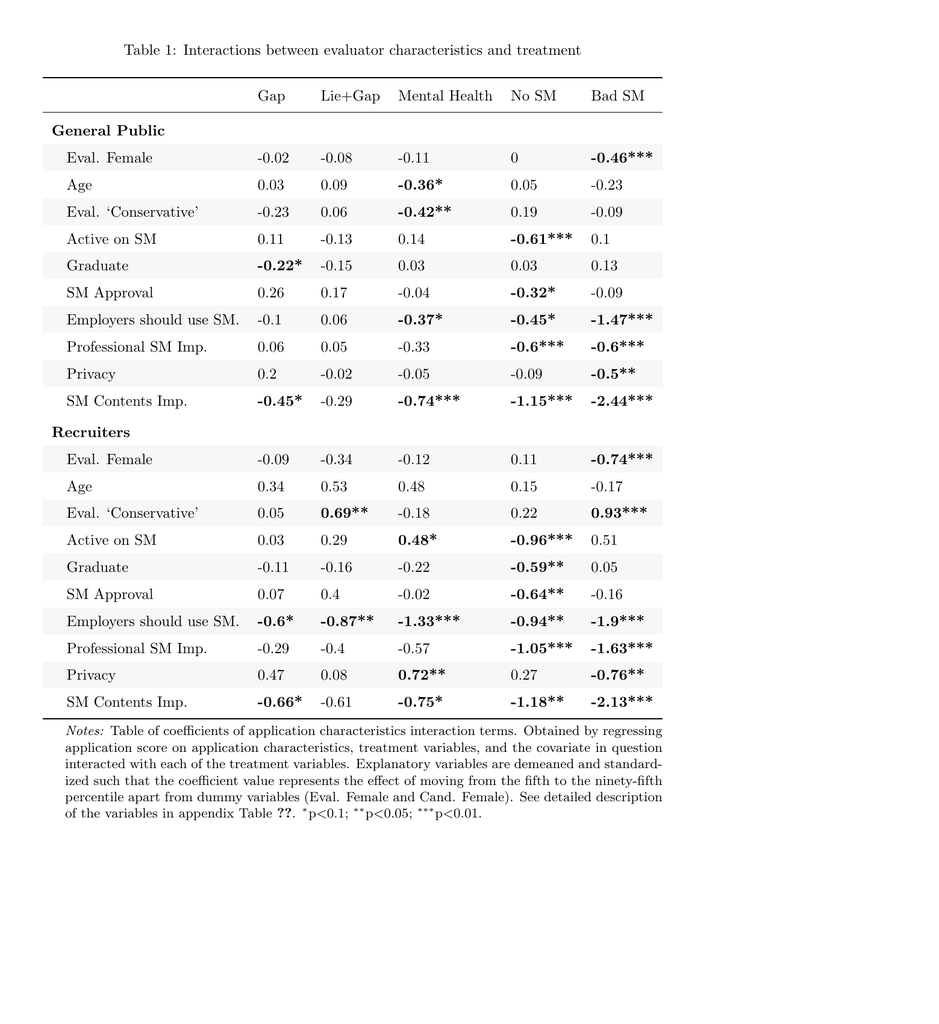

**BH-adjusted stars (50 tests per wave)**

[figure not shown]

# Experimenter Demand: Awareness of Study Purpose

*This section runs only when `note_classifications.csv` exists.*

The LLM classifier coded each evaluator’s free-text feedback note for whether they appeared to believe they were participating in a scientific experiment or a genuine hiring task. Three categories:

- **“experiment”** — evaluator signals awareness of the study
- **“real”** — evaluator treats it as a genuine hiring task
- **“unclear”** — no strong signal either way (the large majority)

If experiment-aware evaluators show inflated treatment effects (especially for Bad SM), this would support an experimenter demand interpretation.

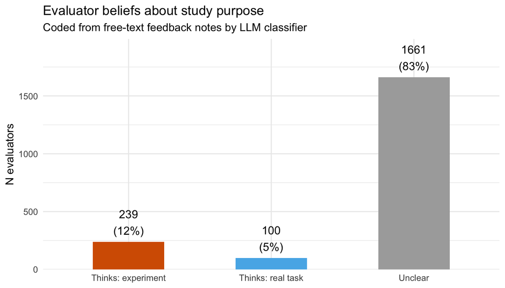

```r
eb_dist = as.data.frame(table(eval_sm$exp_belief))
colnames(eb_dist) = c("Belief","N")
eb_dist$pct    = eb_dist$N / sum(eb_dist$N)
eb_dist$Belief = factor(eb_dist$Belief,
  levels=c("experiment","real","unclear"),
  labels=c("Thinks: experiment","Thinks: real task","Unclear"))

ggplot(eb_dist, aes(x=Belief, y=N, fill=Belief)) +
  geom_col(show.legend=FALSE, width=0.5) +
  geom_text(aes(label=sprintf("%d\n(%.0f%%)", N, pct*100)),
            vjust=-0.3, size=4) +
  scale_fill_manual(values=c("Thinks: experiment"="#D55E00",
                              "Thinks: real task"="#56B4E9",
                              "Unclear"="#AAAAAA")) +
  scale_y_continuous(expand=expansion(mult=c(0, 0.2))) +
  labs(title="Evaluator beliefs about study purpose",
       subtitle="Coded from free-text feedback notes by LLM classifier",
       x=NULL, y="N evaluators") +
  theme_minimal()
```

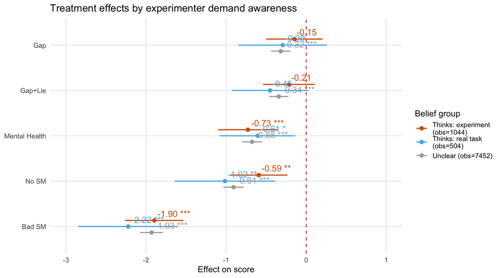

```r
exp_idx     = Res$mturkID %in% eval_sm$mturkID[eval_sm$exp_belief == "experiment"]
real_idx    = Res$mturkID %in% eval_sm$mturkID[eval_sm$exp_belief == "real"]
unclear_idx = Res$mturkID %in% eval_sm$mturkID[eval_sm$exp_belief == "unclear"]
n_exp     = sum(exp_idx     & wave_idx, na.rm=TRUE)
n_real    = sum(real_idx    & wave_idx, na.rm=TRUE)
n_unclear = sum(unclear_idx & wave_idx, na.rm=TRUE)

exp_models = run_subgroup_models(
  formula_vars_cp,
  list(exp_idx, real_idx, unclear_idx),
  split_var = character(0)
)

plot_models(exp_models,
            m.labels     = c(paste0("Thinks: experiment (obs=", n_exp, ")"),
                             paste0("Thinks: real task (obs=", n_real, ")"),
                             paste0("Unclear (obs=", n_unclear, ")")),
            rm.terms     = treats_rm,
            axis.labels  = rev(c("Gap","Gap+Lie","Mental Health","No SM","Bad SM")),
            legend.title = "Belief group",
            show.values  = TRUE,
            dot.size     = 2,
            colors       = c("#AAAAAA","#56B4E9","#D55E00")) +
  geom_hline(yintercept=0, colour="red", linetype="dashed") +
  labs(title="Treatment effects by experimenter demand awareness",
       x=NULL, y="Effect on score") +
  theme_minimal() +
  theme(panel.grid.minor.x=element_blank())
```